# 基因组学数据分析 第一次作业

```bash
Environment:
    R version 3.5.2 (2018-12-20)
    Platform: x86_64-pc-linux-gnu (64-bit)
    Running under: Debian GNU/Linux 10 (buster)
    Coding: UTF-8
```

## College 数据集分析

1. 读入数据

   ```r
   college <- read.csv("./College.csv")
   ```

2. 观察数据

   使用`class()`判断数据类型，使用`dim()`查看大小

   ```r
   class(college)
   ```

   ```
   [1] "data.frame"
   ```

   ```r
   dim(college)
   ```

   ```
   [1] 777  19
   ```

   为 $777\times19$ 的 `data.frame` 类
3. 重置行名

   原本的行列

   ```r
   head(college)
   ```

   ```
                                X Private Apps Accept Enroll Top10perc Top25perc
   1 Abilene Christian University     Yes 1660   1232    721        23        52
   2           Adelphi University     Yes 2186   1924    512        16        29
   3               Adrian College     Yes 1428   1097    336        22        50
   4          Agnes Scott College     Yes  417    349    137        60        89
   5    Alaska Pacific University     Yes  193    146     55        16        44
   6            Albertson College     Yes  587    479    158        38        62
     F.Undergrad P.Undergrad Outstate Room.Board Books Personal PhD Terminal
   1        2885         537     7440       3300   450     2200  70       78
   2        2683        1227    12280       6450   750     1500  29       30
   3        1036          99    11250       3750   400     1165  53       66
   4         510          63    12960       5450   450      875  92       97
   5         249         869     7560       4120   800     1500  76       72
   6         678          41    13500       3335   500      675  67       73
     S.F.Ratio perc.alumni Expend Grad.Rate
   1      18.1          12   7041        60
   2      12.2          16  10527        56
   3      12.9          30   8735        54
   4       7.7          37  19016        59
   5      11.9           2  10922        15
   6       9.4          11   9727        55
   ```

   重置后行列

   ```r
   rownames(college) <- college[, 1]
   college <- college[, -1]
   head(college)
   ```

   ```
                                Private Apps Accept Enroll Top10perc Top25perc
   Abilene Christian University     Yes 1660   1232    721        23        52
   Adelphi University               Yes 2186   1924    512        16        29
   Adrian College                   Yes 1428   1097    336        22        50
   Agnes Scott College              Yes  417    349    137        60        89
   Alaska Pacific University        Yes  193    146     55        16        44
   Albertson College                Yes  587    479    158        38        62
                                F.Undergrad P.Undergrad Outstate Room.Board Books
   Abilene Christian University        2885         537     7440       3300   450
   Adelphi University                  2683        1227    12280       6450   750
   Adrian College                      1036          99    11250       3750   400
   Agnes Scott College                  510          63    12960       5450   450
   Alaska Pacific University            249         869     7560       4120   800
   Albertson College                    678          41    13500       3335   500
                                Personal PhD Terminal S.F.Ratio perc.alumni Expend
   Abilene Christian University     2200  70       78      18.1          12   7041
   Adelphi University               1500  29       30      12.2          16  10527
   Adrian College                   1165  53       66      12.9          30   8735
   Agnes Scott College               875  92       97       7.7          37  19016
   Alaska Pacific University        1500  76       72      11.9           2  10922
   Albertson College                 675  67       73       9.4          11   9727
                                Grad.Rate
   Abilene Christian University        60
   Adelphi University                  56
   Adrian College                      54
   Agnes Scott College                 59
   Alaska Pacific University           15
   Albertson College                   55
   ```

   ```r
   college$Private <- as.numeric(as.factor(college$Private))
   ```

4. 计算Apps和Accept的平均值与相关系数
   - 计算平均值

     ```r
     apps.mean <- mean(college$Apps)
     apps.mean
     ```

     ```
     [1] 3001.638
     ```

     ```r
     accept.mean <- mean(college$Accept)
     accept.mean
     ```

     ```
     [1] 2018.804
     ```

   - 计算相关系数

     ```r
     lm.res <- lm(Accept ~ Apps, college)
     summary(lm.res)
     ```

     ```
     Call:
     lm(formula = Accept ~ Apps, data = college)

     Residuals:
         Min      1Q  Median      3Q     Max
     -6344.8  -154.2   -35.2   184.7  5490.5

     Coefficients:
                  Estimate Std. Error t value Pr(>|t|)
     (Intercept) 2.253e+02  3.692e+01   6.101 1.66e-09 ***
     Apps        5.975e-01  7.542e-03  79.226  < 2e-16 ***
     ---
     Signif. codes:  0 '***' 0.001 '**' 0.01 '*' 0.05 '.' 0.1 ' ' 1

     Residual standard error: 813.1 on 775 degrees of freedom
     Multiple R-squared:  0.8901,    Adjusted R-squared:   0.89
     F-statistic:  6277 on 1 and 775 DF,  p-value: < 2.2e-16
     ```

     可以看到$R^2$统计量为$0.8901$，而在简单线性模型中，相关系数的平方有$r^2=R^2$的关系，因此不难得到$r=\sqrt{R^2}=0.943$
   - 绘制拟合结果

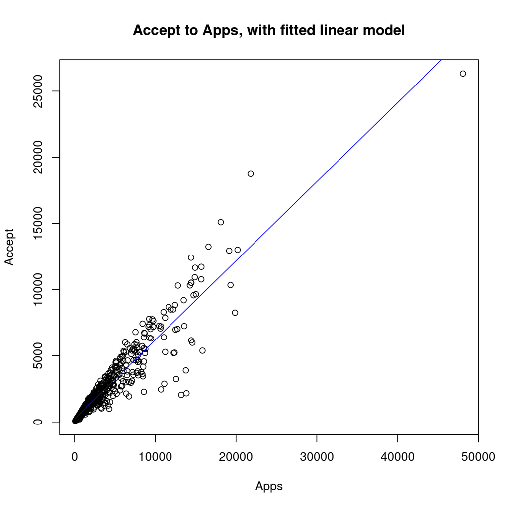

     ```r
     plot(college$Apps, college$Accept, xlab = "Apps", ylab = "Accept", main = "Accept to Apps, with fitted linear model")
     lines(college$Apps, fitted(lm.res), col = "blue")
     ```

5. `summary()`函数的使用

   ```r
   summary(college[, 1:3])
   ```

   ```
       Private           Apps           Accept
    Min.   :1.000   Min.   :   81   Min.   :   72
    1st Qu.:1.000   1st Qu.:  776   1st Qu.:  604
    Median :2.000   Median : 1558   Median : 1110
    Mean   :1.727   Mean   : 3002   Mean   : 2019
    3rd Qu.:2.000   3rd Qu.: 3624   3rd Qu.: 2424
    Max.   :2.000   Max.   :48094   Max.   :26330
   ```

   其中`1st Qu.`为第一四分位点，表示约有25%的数据在此值以下；`3rd Qu.`为第三四分位点，表示约有75%的数据在此值以下
6. `pairs()`函数作图

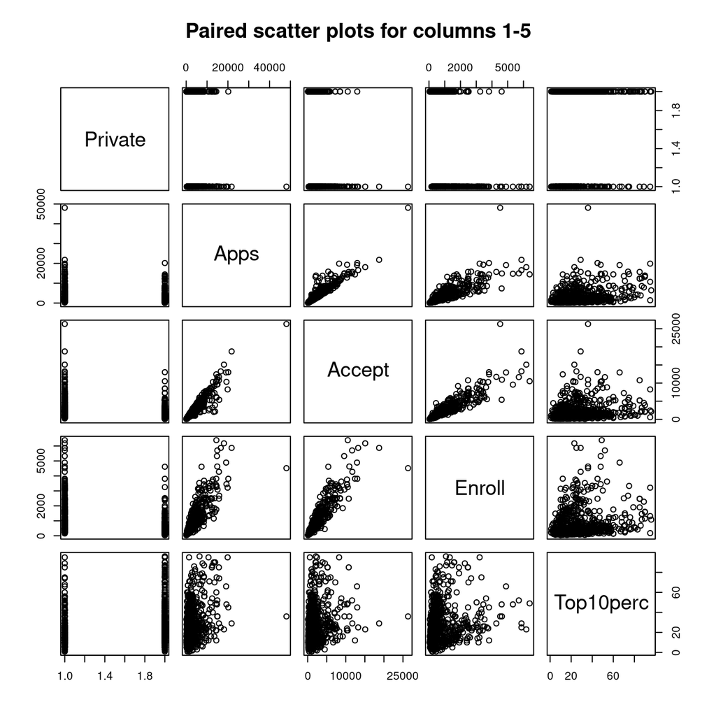

   ```r
   pairs(college[, 1:5], main = "Paired scatter plots for columns 1-5")
   ```

7. `plot()`与`boxplot()`作图

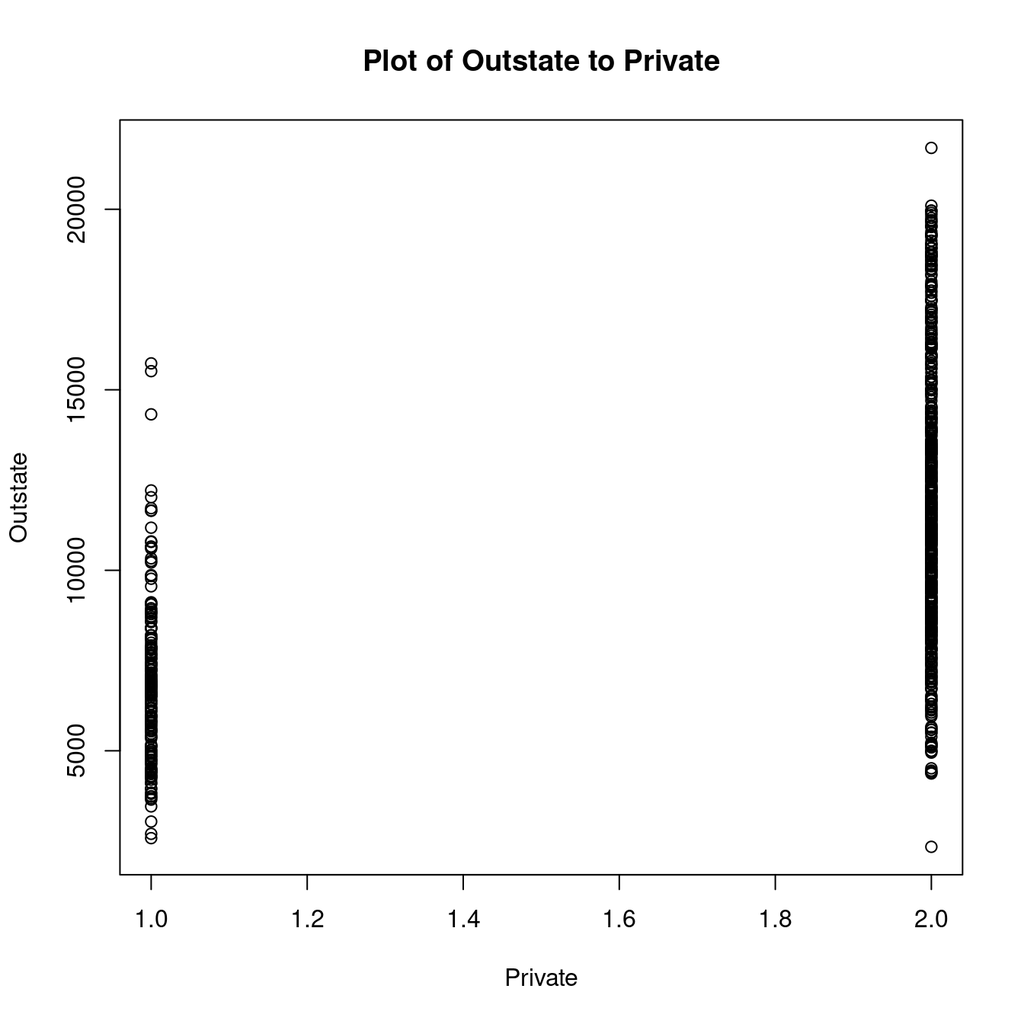

   ```r
   plot(college$Private, college$Outstate, ylab = "Outstate", xlab = "Private", main = "Plot of Outstate to Private")
   ```

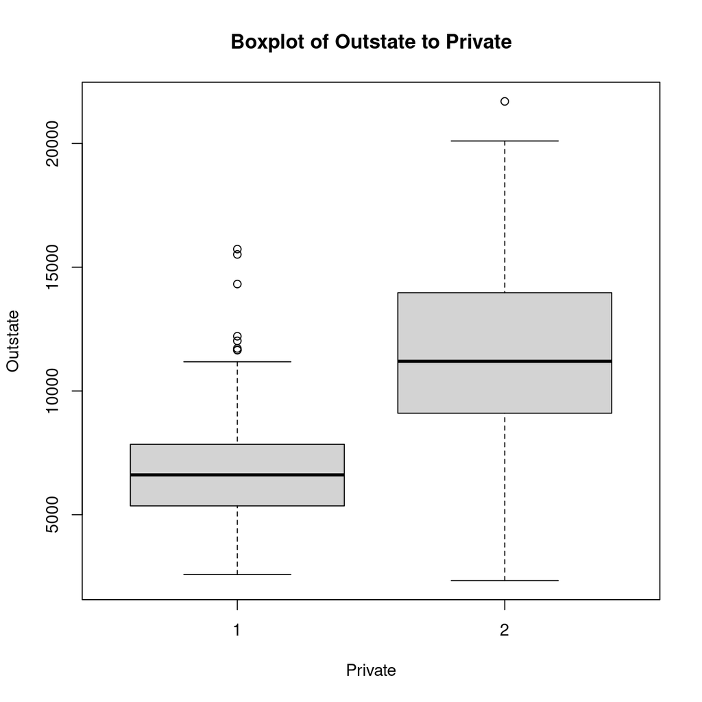

   ```r
   boxplot(college$Outstate ~ college$Private, ylab = "Outstate", xlab = "Private", main = "Boxplot of Outstate to Private")
   ```

   > `boxplot()`函数第一项参数为`formula`，而不接受分开的$X$与$Y$

   ```r
   college["Elite"] <- ifelse(college$Top10perc >= 50, "Yes", "No")
   head(college)
   ```

   ```
                                Private Apps Accept Enroll Top10perc Top25perc
   Abilene Christian University       2 1660   1232    721        23        52
   Adelphi University                 2 2186   1924    512        16        29
   Adrian College                     2 1428   1097    336        22        50
   Agnes Scott College                2  417    349    137        60        89
   Alaska Pacific University          2  193    146     55        16        44
   Albertson College                  2  587    479    158        38        62
                                F.Undergrad P.Undergrad Outstate Room.Board Books
   Abilene Christian University        2885         537     7440       3300   450
   Adelphi University                  2683        1227    12280       6450   750
   Adrian College                      1036          99    11250       3750   400
   Agnes Scott College                  510          63    12960       5450   450
   Alaska Pacific University            249         869     7560       4120   800
   Albertson College                    678          41    13500       3335   500
                                Personal PhD Terminal S.F.Ratio perc.alumni Expend
   Abilene Christian University     2200  70       78      18.1          12   7041
   Adelphi University               1500  29       30      12.2          16  10527
   Adrian College                   1165  53       66      12.9          30   8735
   Agnes Scott College               875  92       97       7.7          37  19016
   Alaska Pacific University        1500  76       72      11.9           2  10922
   Albertson College                 675  67       73       9.4          11   9727
                                Grad.Rate Elite
   Abilene Christian University        60    No
   Adelphi University                  56    No
   Adrian College                      54    No
   Agnes Scott College                 59   Yes
   Alaska Pacific University           15    No
   Albertson College                   55    No
   ```

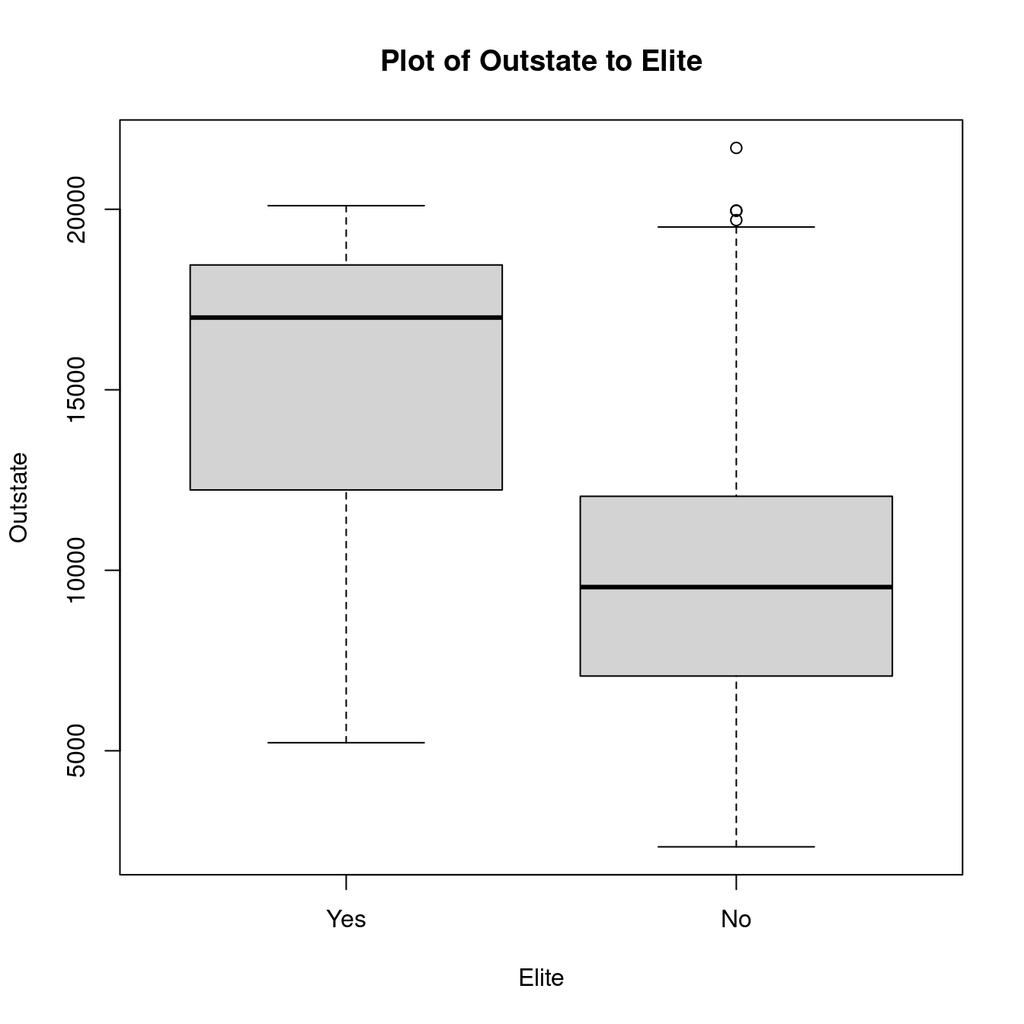

   ```r
   plot(factor(college$Elite, levels = c("Yes", "No")), college$Outstate, xlab = "Elite", ylab = "Outstate", main = "Plot of Outstate to Elite")
   ```

   > 这里使用了`factor()`函数内的`levels`参数，将`factor`类型的默认排序由字典序变为了自定义的顺序
9. `hist()`函数作图

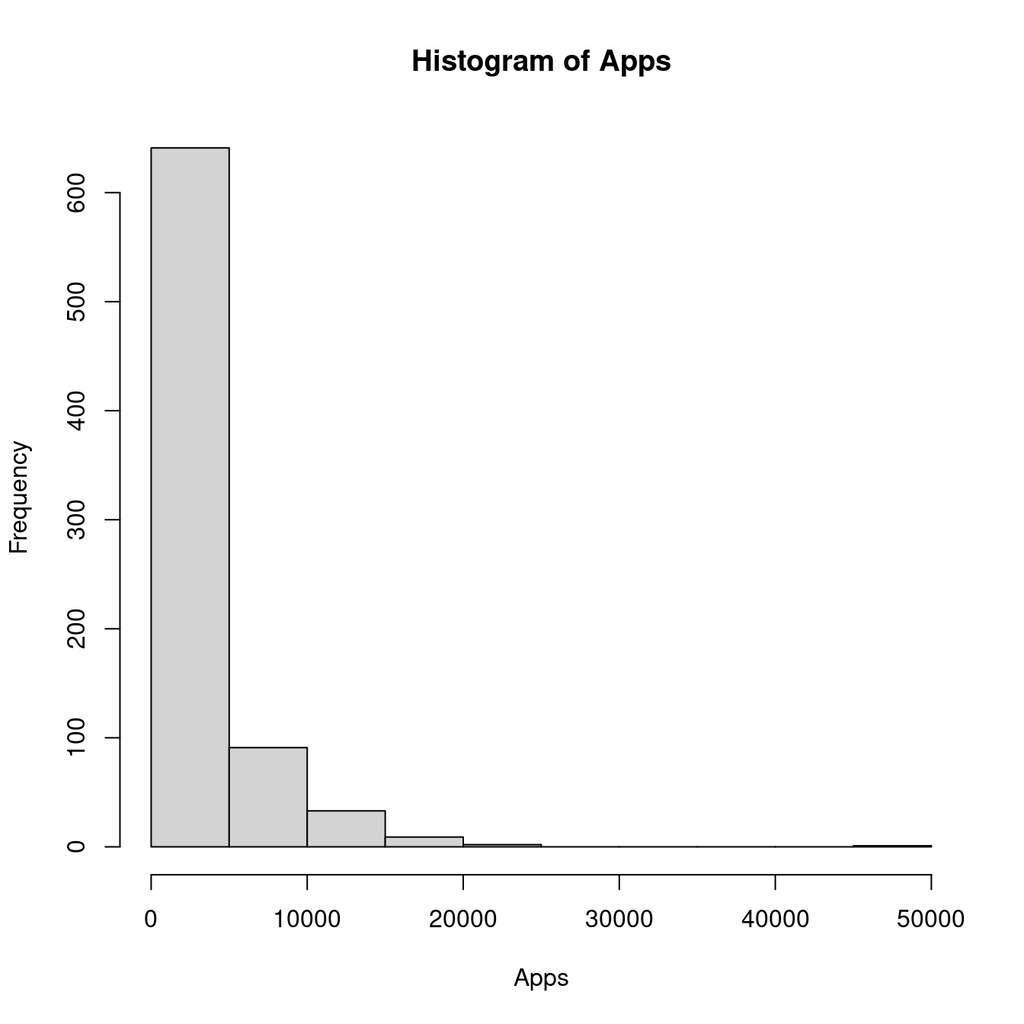

   ```r
   hist(college$Apps, xlab = "Apps", main = "Histogram of Apps")
   ```

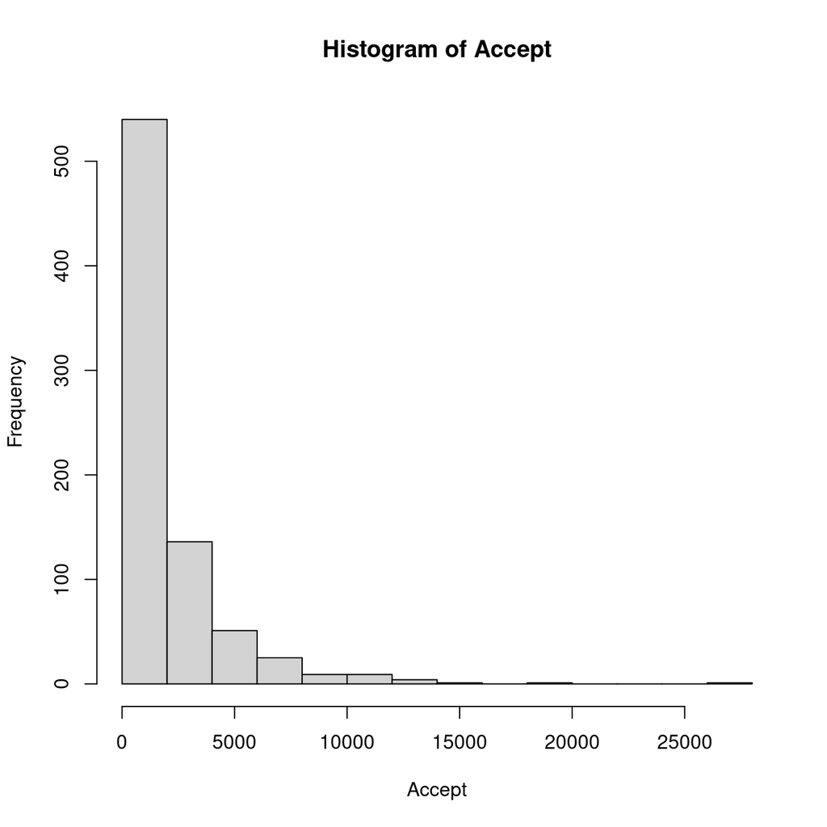

   ```r
   hist(college$Accept, xlab = "Accept", main = "Histogram of Accept")
   ```

   > 此处可以不传入`main`参数，`hist()`对此参数有默认取值
10. 数据写入本地

    ```r
    write.csv(college, file = "./College.new.csv")
    ```

## Auto 数据集分析

11. 读入数据

    此数据集中存在缺失值，不方便处理，故将整行刨去

    ```r
    auto <- read.csv("./Auto.csv", na.string = "?")
    auto <- na.omit(auto)
    ```

12. 简单线性回归

    ```r
    lm.res <- lm(mpg ~ horsepower, auto)
    summary(lm.res)
    ```

    ```
    Call:
    lm(formula = mpg ~ horsepower, data = auto)

    Residuals:
         Min       1Q   Median       3Q      Max
    -13.5710  -3.2592  -0.3435   2.7630  16.9240

    Coefficients:
                 Estimate Std. Error t value Pr(>|t|)
    (Intercept) 39.935861   0.717499   55.66   <2e-16 ***
    horsepower  -0.157845   0.006446  -24.49   <2e-16 ***
    ---
    Signif. codes:  0 '***' 0.001 '**' 0.01 '*' 0.05 '.' 0.1 ' ' 1

    Residual standard error: 4.906 on 390 degrees of freedom
    Multiple R-squared:  0.6059,    Adjusted R-squared:  0.6049
    F-statistic: 599.7 on 1 and 390 DF,  p-value: < 2.2e-16
    ```

    ```r
    confint(lm.res)
    ```

    ```
                    2.5 %     97.5 %
    (Intercept) 38.525212 41.3465103
    horsepower  -0.170517 -0.1451725
    ```

    - **预测变量和响应变量之间有关系吗**

      有关系（$R^2=0.6059$）
    - **关系有多强**

      从$R^2=0.6059$来看，仅有不到$\frac{2}{3}$的响应变量中的差异能够被预测变量所解释，因此关系并不强
    - **是正相关还是负相关**

      从`horsepower`的系数为$-0.157845<0$来看，为负相关
    - **当`horsepower`为98时，`mpg`的预测值为多少，相应的95%置信区间与预测区间分别为多少**

      ```r
      predict(lm.res, data.frame(horsepower = 98), interval = "confidence")
      ```

      ```
             fit      lwr      upr
      1 24.46708 23.97308 24.96108
      ```

      ```r
      predict(lm.res, data.frame(horsepower = 98), interval = "prediction")
      ```

      ```
             fit     lwr      upr
      1 24.46708 14.8094 34.12476
      ```

      故`mpg`预测值为$24.46708$，95%置信区间为$(23.97308,24.96108)$，预测区间为$(14.8094,34.12476)$
13. 绘制关系图与最小二乘回归线

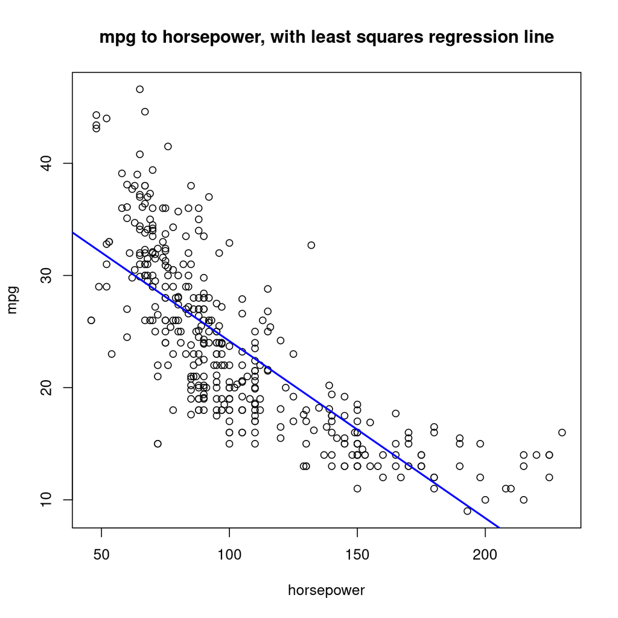

    ```r
    plot(auto$horsepower, auto$mpg, xlab = "horsepower", ylab = "mpg", main = "mpg to horsepower, with least squares regression line")
    abline(lm.res, lwd = 2, col = "blue")
    ```

14. 最小二乘回归拟合诊断图

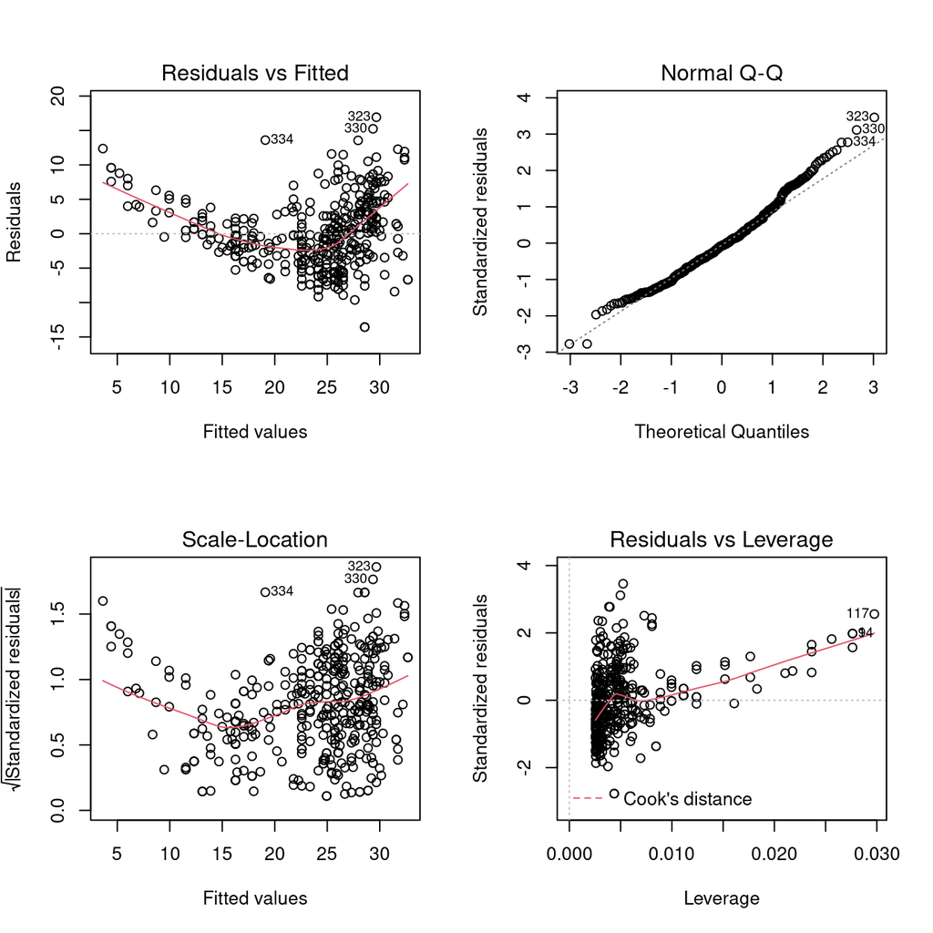

    ```r
    par(mfrow = c(2, 2))
    plot(lm.res)
    ```

    从图中不难看出，只有靠近中段百分位的拟合程度较好。观察杠杆值图，不难发现杠杆值较小的点随在一较大的残差波动范围内，但总体残差较小，比较集中；杠杆值大致处于中间的数据点残差相对来说较小；杠杆值大的数据点又明显有较大残差；反映在结果上就是两端的数据点和中间腹部的数据点都拟合较差，出现了相反方向的偏离预测模型。